# RNAseq Cártamo

Diego G. Teixeira

Gerado em 2019-08-02

## Introdução

Esse é o protocolo de análises em bioinformática de dados de RNA seq provenientes de cártamo. O dado é composto por 4 bilbiotecas (2 de amostra controle e 2 de amostra tratada com NaCl) sequencinados em ION TORRENT.

As bibliotecas são:

- IonXpressRNA_005.Controle1.2014-02-10T04_44_50Z.318C.fastq -> C1
- IonXpressRNA_006.Controle2.2014-02-10T04_44_50Z.318C.fastq -> C2
- IonXpressRNA_007.N1.2014-02-10T23_29_46Z.318C.fastq -> N1
- IonXpressRNA_008.N2.2014-02-10T23_29_46Z.318C.fastq -> N2

# Pré-análises

### Controle de qualidade das reads

Para avaliar a qualidade das reads sequenciadas, foi utilizado o software [Fastqc](https://www.bioinformatics.babraham.ac.uk/projects/fastqc/).

Características das reads

| Biblioteca | # sequências | Comprimento | %GC |
| --- | --- | --- | --- |
| C1 | 1365359 | 25-342 | 52 |
| C2 | 1218666 | 25-347 | 52 |
| N1 | 1430210 | 25-362 | 52 |
| N2 | 1877348 | 25-350 | 53 |

Observando a qualidade de acordo com a posição da base dentro das reads, é identificado que o quaril inferior, do BoxWhisker plot, alcança a região de baixa qualidade a partir da posição 270:

- A linha vermelha central como o valor da mediana
- A caixa amarela representa a faixa interquartil (25-75%)
- As linhas inferiores e superiores indicam os 10% e 90% dos pontos
- A linha azul representa a qualidade média

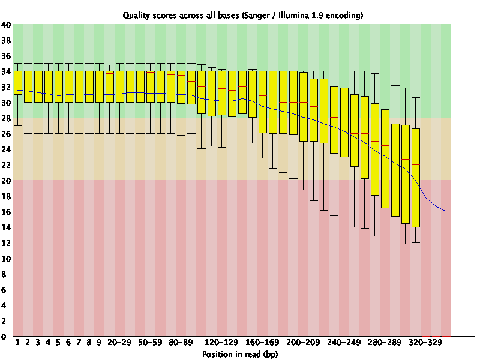

C1

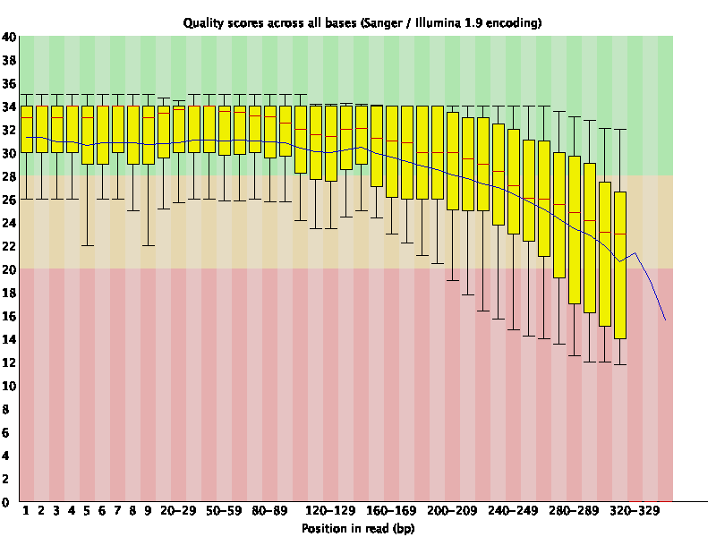

C2

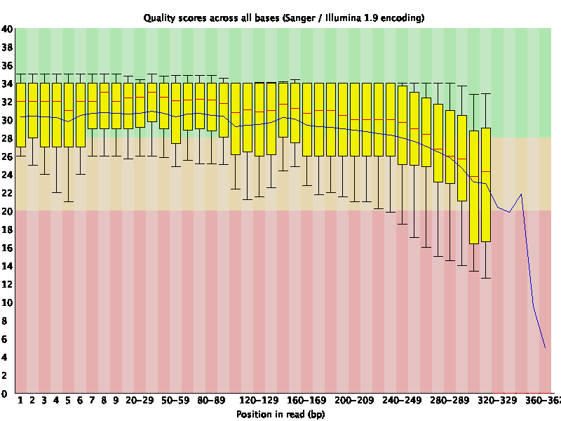

N1

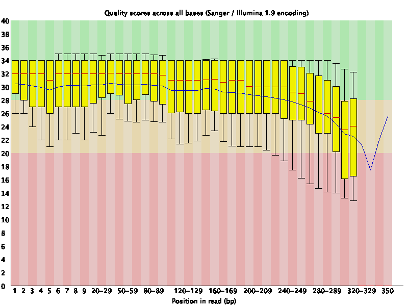

N2

Para melhorar a qualidade das reads, foi realizado um corte nas bases das reads com comprimento superior a 260pb utilizando a ferramenta seqtk.

*comando:* ~/Programs/seqtk/seqtk trimfq -e 260 C1 > C1.trim.fastq.

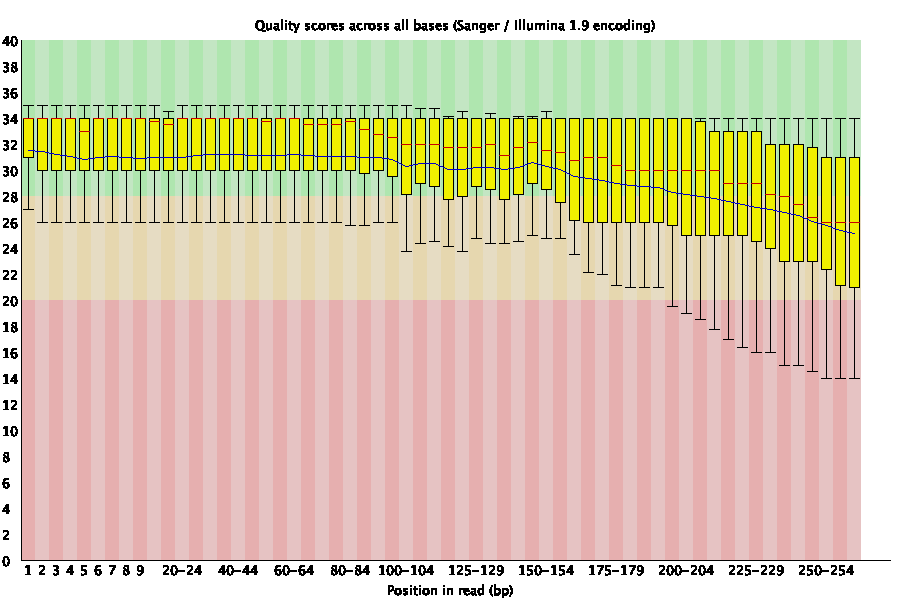

C1 trim

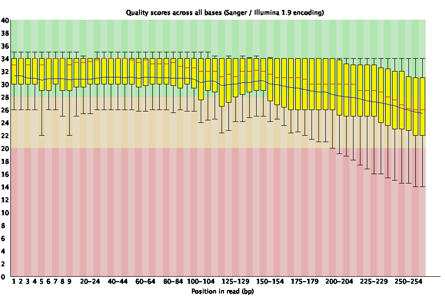

C2 trim

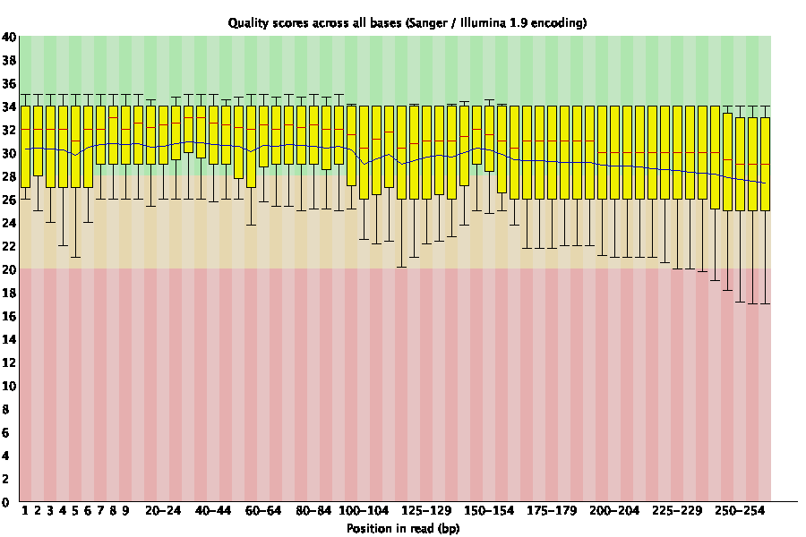

N1 trim

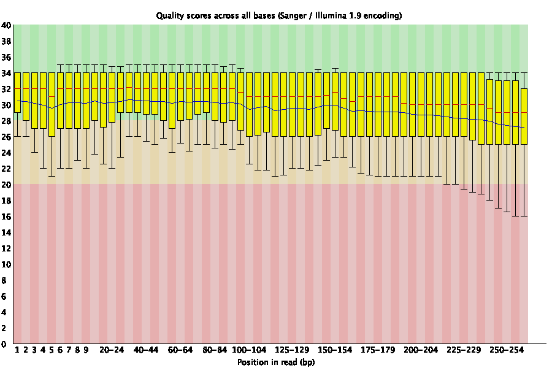

N2 trim

# Mapeamento

### Abordagem 1: Mapeamento contra o genoma de *Heliantus annuus*

o arquivos fasta e a anotação em gff3 de *Heliantus annuus* foram obtidos através do [Ensembl plants](http://plants.ensembl.org/info/website/ftp/index.html). Em seguida o arquivo fasta foi indexado pelo programa [Hisat2](https://ccb.jhu.edu/software/hisat2/index.shtml). Ainda utilizando o Hisat2, as reads foram mapeadas ao genoma.

*Comando:* hisat2 -p 14 -x H_annuus/Helianthus_annuus -U trimed/N2.trim.fastq -S sam/N2.sam

Mapeamento contra o genoma de H. annuus

| Biblioteca | # reads | Não mapeada | Alinhada 1x | Alinhada >1x | % de mapeamento |
| --- | --- | --- | --- | --- | --- |
| C1 | 1365359 | 1213232 | 73009 | 79118 | 11.14 |
| C2 | 1218666 | 1073805 | 67421 | 77440 | 11.89 |
| N1 | 1430210 | 1190019 | 119473 | 120718 | 16.79 |
| N2 | 1877348 | 1636663 | 113928 | 126757 | 12.82 |